# GBM_Volumetrics

## Extracting Volumetric Features of Glioblastoma

Volumetric features including Contrast Enhancing (CE) region and Necrotic (NE) regions of Glioblastoma (GBM) have strong associations with biological pathways and patient outcomes [1]. In the take-home assignment, one MR image (3D_WAND_T1_WEIGHTED.nrrd) and an associated label file (3D_WAND_T1_WEIGHTED-label.nrrd) were provided in the GBM folder. The label file provided a mask for the GBM that is present in the MRI.

### Implementation

The code below performs the following tasks:

- Separates the tumor region into Contrast enhancing and necrotic regions
  - Read image and label file
  - Smooth image using an edge-preserving filter (Curvature flow) for denoising
  - Apply tumor mask obtained from label file
  - On masked image, compute automated threshold to separate CE and NE regions
  - Generate label image with background label 0, NE label 1, and CE label 2
  - Write out image file
- Computes volumes of these regions
  - Compute volumes and write out a CSV file

### Programming details

- Simple ITK is an open-source image analysis toolkit that is built on top of ITK. I'm using the Python distribution for the code below [2,3].

```python
import SimpleITK as sitk
import os
import matplotlib.pyplot as plt
```

```python
# read the images
image_Filename = '../Data/3D_WAND_T1_WEIGHTED.nrrd'
image = sitk.ReadImage(image_Filename)
GBMmask = sitk.ReadImage(image_Filename[:-5]+'-label.nrrd')
```

```python
# Show image in ImageJ
IMAGEJ_PATH = 'C:\\Program Files\\ImageJ'
os.environ['PATH'] = IMAGEJ_PATH + ';' + os.environ['PATH']
sitk.Show(image, title='Original image')
```

This opens the image in ImageJ enabling interacting with the image

### ImageJ Screenshot

[figure not shown]

```python
# function to show image using matplotlib
def myshow(img, title=None, margin=0.05, dpi=80):
    nda = sitk.GetArrayViewFromImage(img)
    spacing = img.GetSpacing()

    if nda.ndim == 3:
        # fastest dim, either component or x
        c = nda.shape[-1]

        # the the number of components is 3 or 4 consider it an RGB image
        if not c in (3,4):
            nda = nda[nda.shape[0]//2,:,:]

    elif nda.ndim == 4:
        c = nda.shape[-1]

        if not c in (3,4):
            raise Runtime("Unable to show 3D-vector Image")

        # take a z-slice
        nda = nda[nda.shape[0]//2,:,:,:]

    ysize = nda.shape[0]
    xsize = nda.shape[1]

    # Make a figure big enough to accommodate an axis of xpixels by ypixels
    # as well as the ticklabels, etc...
    figsize = (1 + margin) * ysize / dpi, (1 + margin) * xsize / dpi

    fig = plt.figure(figsize=figsize, dpi=dpi)
    # Make the axis the right size...
    ax = fig.add_axes([margin, margin, 1 - 2*margin, 1 - 2*margin])

    extent = (0, xsize*spacing[1], ysize*spacing[0], 0)

    t = ax.imshow(nda,extent=extent,interpolation=None)

    if nda.ndim == 2:
        t.set_cmap("gray")

    if(title):
        plt.title(title)
    plt.show()
```

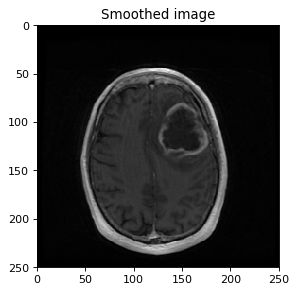

```python
# apply edge-preserving smoothing to denoise
blurFilter = sitk.CurvatureFlowImageFilter()
blurFilter.SetNumberOfIterations(4)
blurFilter.SetTimeStep(0.08)
blurredimage=blurFilter.Execute(image)
myshow(blurredimage[:,:,80], title='Smoothed image')
```

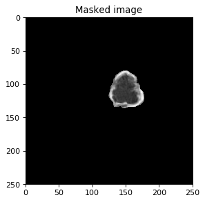

```python
# apply mask
msk = sitk.MaskImageFilter()
masked_image=msk.Execute(blurredimage, GBMmask)
myshow(masked_image[:,:,80], title='Masked image')
```

```python
# Find threshold that separates high intensity CE and low intensity NE regions
otsu_filter = sitk.OtsuThresholdImageFilter()
otsu_filter.SetInsideValue(1)
otsu_filter.SetOutsideValue(2)
segmented = otsu_filter.Execute(masked_image)
print('Otsu threshold value=', otsu_filter.GetThreshold() )
```

```
Otsu threshold value= 53.73164749145508
```

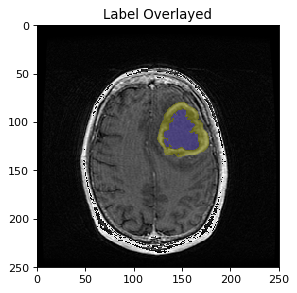

```python
# segmented now has the label 1 for NE as well as background, and 2 for CE regions
# Applying original mask to obtain 0 for background, 1 for NE, and 2 for CE regions
segmented_final = msk.Execute(segmented, GBMmask)
myshow(sitk.LabelOverlay(sitk.Cast(image[:,:,80],sitk.sitkUInt8), segmented_final[:,:,80]*50,0.5), title="Label Overlayed")
```

```python
# compute volumes and display as table
import pandas as pd
import numpy as np
voxel_dims = image.GetSpacing()

voxel_volume=np.prod(voxel_dims)*0.001 # converting mm^3 to cm^3
```

```python
from IPython.display import display, HTML

image_array = sitk.GetArrayFromImage(image)
seg_array = sitk.GetArrayFromImage(segmented_final)
total_volume = np.sum(seg_array>0)*voxel_volume #in cubic centimeters
NE_volume = np.sum(seg_array==1)*voxel_volume
CE_volume = np.sum(seg_array==2)*voxel_volume

df = pd.DataFrame({'Filename': [image_Filename],
                   'NEvolume': [NE_volume],
                   'CEvolume': [CE_volume],  'Totalvolume': [total_volume]}, columns = ['Filename','NEvolume','CEvolume', 'Totalvolume'])

display(df)

df.to_csv('Volumes.csv',sep=',', index=False)
```

|  | Filename | NEvolume | CEvolume | Totalvolume |
| --- | --- | --- | --- | --- |
| 0 | ../Data/3D_WAND_T1_WEIGHTED.nrrd | 18.778955 | 51.594441 | 70.373396 |

```python
# Write out segmentations as new labelfile
sitk.WriteImage(segmented_final,'3D_WAND_T1_WEIGHTED-label-CENElabel.nrrd')
```

### References

[1]Grossmann, Patrick et al. “Imaging-Genomics Reveals Driving Pathways of MRI Derived Volumetric Tumor Phenotype Features in Glioblastoma.” BMC Cancer 16 (2016): 611. PMC. Web. 18 Dec. 2017. https://www.ncbi.nlm.nih.gov/pmc/articles/PMC4977720/

[2]http://www.simpleitk.org/

[3]Z. Yaniv, B. C. Lowekamp, H. J. Johnson, R. Beare, "SimpleITK Image-Analysis Notebooks: a Collaborative Environment for Education and Reproducible Research", J Digit Imaging., https://doi.org/10.1007/s10278-017-0037-8, 2017